# Homework 6: Association rules

```r
suppressMessages(library(arules))
```

```r
suppressMessages(library(arulesViz))
data1<-read.csv("Uk Trainings.csv")
```

```r
install.packages("dummies", repos = "http://cran.us.r-project.org")
suppressMessages(library(dummies))
```

I have converted Sector and Venue variables into dummy variables in order to be able to create rules which include these variables.

```r
data2 <- dummy.data.frame(data1, names=c("Sector","Venue"),sep = ".")
names(data2)
```

```
##  [1] "id"
##  [2] "Total.spend"
##  [3] "Sector.Central Gov\\t"
##  [4] "Sector.Commercial"
##  [5] "Sector.Education"
##  [6] "Sector.Health"
##  [7] "Sector.Local Gov\\t"
##  [8] "Venue.Belfast"
##  [9] "Venue.Edinburgh"
## [10] "Venue.IDM"
## [11] "Venue.Manchester"
## [12] "Venue.Newcastle"
## [13] "Venue.Sheffield"
## [14] "Venue.SPSS WOKING"
## [15] "Number.of.courses"
```

[output cut: 21 more lines]

Average value of the total spendings on the courses are $562.3128 dollars.

```r
mean(data2$Total.spend)
```

```
## [1] 562.3128
```

In order to be able to include the spendings in the analysis I converted the spendings into factor variable in the following way: customers who paid less than $562,3128 were encoded as 0, and people who paid more than the average value were encoded as 1.

```r
data2$Total.spend<-ifelse(data2$Total.spend<562.3128,0,1)
```

I have excluded from the dataset the first variable which is ID.Also, I have excluded the variable Number of courses as I think that it is the result after choosing courses.

```r
data2<-data2[,-1]
data2<-data2[,-14]
```

```r
data<-as.matrix(data2)
txn<-as(data, "transactions")
```

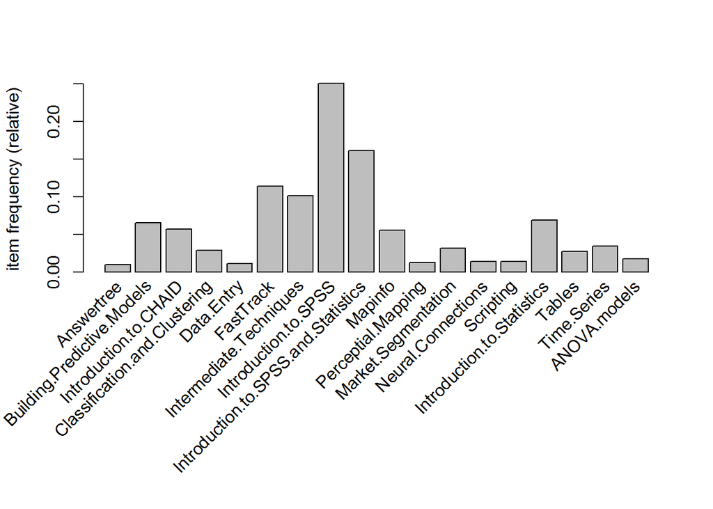

```r
itemFrequencyPlot(txn[,(17:34)])
```

As we can see from the frequency chart, the most 3 demanded corses are “Introduction to SPSS”,“Introduction to SPSS and Statistics”, “Fast Track”.

First, I have run rules only for courses to understand which courses are chosen with others.

# Rules only for courses

```r
rules <- apriori(txn[,17:34], parameter = list(minlen = 2, maxlen = 4,
                                   supp = 0.001, conf = 0.001))
```

```
## Apriori
##
## Parameter specification:
##  confidence minval smax arem  aval originalSupport maxtime support minlen
##       0.001    0.1    1 none FALSE            TRUE       5   0.001      2
##  maxlen target   ext
##       4  rules FALSE
##
## Algorithmic control:
##  filter tree heap memopt load sort verbose
##     0.1 TRUE TRUE  FALSE TRUE    2    TRUE
##
## Absolute minimum support count: 2
##
## set item appearances ...[0 item(s)] done [0.00s].
## set transactions ...[18 item(s), 2136 transaction(s)] done [0.00s].
## sorting and recoding items ... [18 item(s)] done [0.00s].
## creating transaction tree ... done [0.00s].
## checking subsets of size 1 2 3 4
```

```
##  done [0.00s].
## writing ... [2824 rule(s)] done [0.00s].
## creating S4 object  ... done [0.00s].
```

```r
rules_sort<-sort(rules, by="lift")
inspect(rules_sort[1:50])
```

```
##      lhs                                rhs                      support confidence      lift
## [1]  {Mapinfo,
##       Perceptial.Mapping,
##       ANOVA.models}                  => {Answertree}         0.001404494  1.0000000 106.80000
## [2]  {Perceptial.Mapping,
##       Market.Segmentation,
##       ANOVA.models}                  => {Answertree}         0.001404494  1.0000000 106.80000
## [3]  {Building.Predictive.Models,
##       Mapinfo,
##       Perceptial.Mapping}            => {Answertree}         0.001404494  1.0000000 106.80000
## [4]  {Introduction.to.CHAID,
##       Intermediate.Techniques,
##       Introduction.to.SPSS}          => {Answertree}         0.001872659  0.8000000  85.44000
## [5]  {Answertree,
##       Mapinfo}                       => {Perceptial.Mapping} 0.001404494  1.0000000  82.15385
## [6]  {Answertree,
##       Mapinfo,
##       ANOVA.models}                  => {Perceptial.Mapping} 0.001404494  1.0000000  82.15385
## [7]  {Answertree,
##       Mapinfo,
##       Market.Segmentation}           => {Perceptial.Mapping} 0.001404494  1.0000000  82.15385
## [8]  {Answertree,
##       Building.Predictive.Models,
##       Mapinfo}                       => {Perceptial.Mapping} 0.001404494  1.0000000  82.15385
## [9]  {Mapinfo,
##       Perceptial.Mapping,
##       Market.Segmentation}           => {Answertree}         0.001404494  0.7500000  80.10000
## [10] {Introduction.to.CHAID,
##       Introduction.to.SPSS,
##       ANOVA.models}                  => {Answertree}         0.001404494  0.7500000  80.10000
## [11] {Classification.and.Clustering,
##       Intermediate.Techniques,
##       Market.Segmentation}           => {Answertree}         0.001404494  0.7500000  80.10000
## [12] {Classification.and.Clustering,
##       Tables,
##       Time.Series}                   => {Data.Entry}         0.001872659  0.8000000  74.29565
## [13] {Building.Predictive.Models,
##       Intermediate.Techniques,
##       Market.Segmentation}           => {Answertree}         0.001872659  0.6666667  71.20000
## [14] {Intermediate.Techniques,
```

[output cut: 91 more lines]

```
## [46] {Classification.and.Clustering,
##       Intermediate.Techniques,
##       Introduction.to.Statistics}    => {Answertree}         0.001404494  0.5000000  53.40000
## [47] {Classification.and.Clustering,
##       Intermediate.Techniques,
##       Introduction.to.SPSS}          => {Answertree}         0.001404494  0.5000000  53.40000
## [48] {Introduction.to.CHAID,
##       Intermediate.Techniques,
##       Market.Segmentation}           => {Answertree}         0.001872659  0.5000000  53.40000
## [49] {Building.Predictive.Models,
##       Intermediate.Techniques,
##       Introduction.to.SPSS}          => {Answertree}         0.001872659  0.5000000  53.40000
## [50] {Mapinfo,
##       Market.Segmentation,
##       Introduction.to.Statistics}    => {Perceptial.Mapping} 0.001404494  0.6000000  49.29231
```

```r
rules_df<-as(rules, "data.frame")
```

[output not shown]

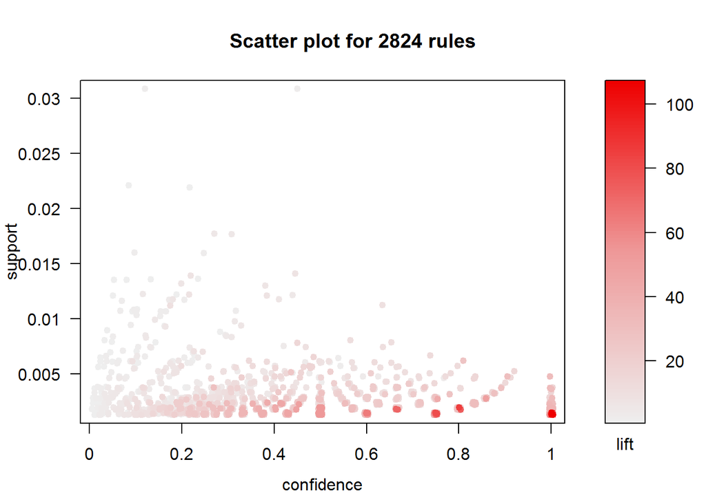

```r
plot(rules, type="scatterplot",
     measure=c("confidence", "support"), shading="lift")
```

```r
rules_1<-subset(rules, rhs %in% 'Introduction.to.SPSS')
rules_1_sort<-sort(rules_1,by="lift")
inspect(rules_1_sort[1:20])
```

```
##      lhs                                      rhs                        support confidence     lift
## [1]  {Introduction.to.CHAID,
##       Data.Entry}                          => {Introduction.to.SPSS} 0.001404494  1.0000000 3.985075
## [2]  {Answertree,
##       Introduction.to.CHAID}               => {Introduction.to.SPSS} 0.002808989  1.0000000 3.985075
## [3]  {Answertree,
##       Introduction.to.CHAID,
##       ANOVA.models}                        => {Introduction.to.SPSS} 0.001404494  1.0000000 3.985075
## [4]  {Answertree,
##       Classification.and.Clustering,
##       Market.Segmentation}                 => {Introduction.to.SPSS} 0.001872659  1.0000000 3.985075
## [5]  {Answertree,
##       Introduction.to.CHAID,
##       Classification.and.Clustering}       => {Introduction.to.SPSS} 0.001872659  1.0000000 3.985075
## [6]  {Answertree,
##       Building.Predictive.Models,
##       Classification.and.Clustering}       => {Introduction.to.SPSS} 0.001872659  1.0000000 3.985075
## [7]  {Answertree,
##       Introduction.to.CHAID,
##       Market.Segmentation}                 => {Introduction.to.SPSS} 0.002340824  1.0000000 3.985075
## [8]  {Answertree,
##       Intermediate.Techniques,
##       Market.Segmentation}                 => {Introduction.to.SPSS} 0.001872659  1.0000000 3.985075
## [9]  {Answertree,
##       Introduction.to.CHAID,
##       Introduction.to.Statistics}          => {Introduction.to.SPSS} 0.001404494  1.0000000 3.985075
## [10] {Answertree,
##       Building.Predictive.Models,
##       Introduction.to.CHAID}               => {Introduction.to.SPSS} 0.002340824  1.0000000 3.985075
## [11] {Answertree,
##       Introduction.to.CHAID,
##       Intermediate.Techniques}             => {Introduction.to.SPSS} 0.001872659  1.0000000 3.985075
## [12] {Answertree,
##       Building.Predictive.Models,
##       Intermediate.Techniques}             => {Introduction.to.SPSS} 0.001872659  1.0000000 3.985075
## [13] {Introduction.to.CHAID,
##       Mapinfo,
##       Perceptial.Mapping}                  => {Introduction.to.SPSS} 0.001404494  1.0000000 3.985075
## [14] {Building.Predictive.Models,
##       Classification.and.Clustering,
##       Intermediate.Techniques}             => {Introduction.to.SPSS} 0.002808989  0.8571429 3.415778
## [15] {Building.Predictive.Models,
##       Introduction.to.SPSS.and.Statistics,
##       Introduction.to.Statistics}          => {Introduction.to.SPSS} 0.002340824  0.8333333 3.320896
## [16] {Classification.and.Clustering,
##       Introduction.to.Statistics,
##       Time.Series}                         => {Introduction.to.SPSS} 0.001872659  0.8000000 3.188060
## [17] {Building.Predictive.Models,
##       Introduction.to.CHAID,
##       Introduction.to.Statistics}          => {Introduction.to.SPSS} 0.003277154  0.7777778 3.099502
## [18] {Introduction.to.CHAID,
##       Market.Segmentation,
##       Introduction.to.Statistics}          => {Introduction.to.SPSS} 0.004681648  0.7692308 3.065442
## [19] {Data.Entry,
##       Tables}                              => {Introduction.to.SPSS} 0.001404494  0.7500000 2.988806
## [20] {Classification.and.Clustering,
##       Data.Entry}                          => {Introduction.to.SPSS} 0.001404494  0.7500000 2.988806
```

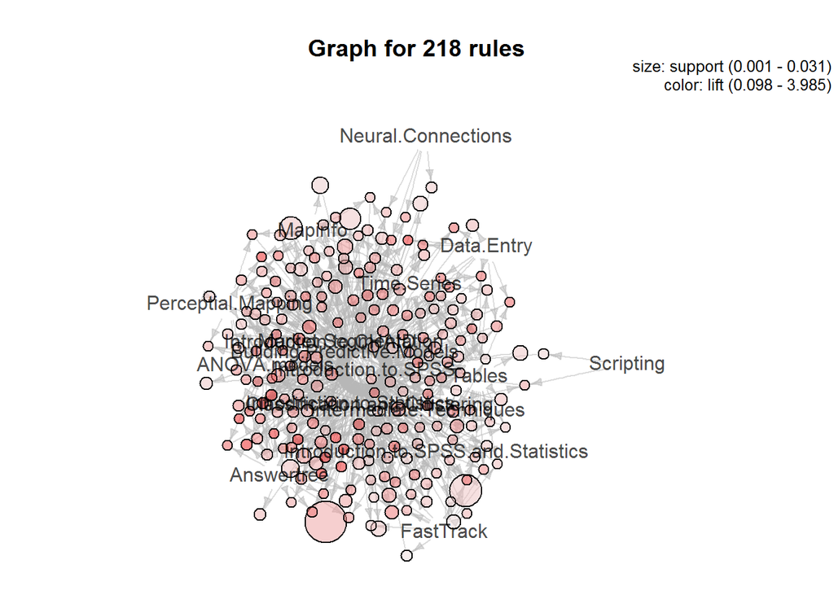

```r
plot(rules_1, method="graph")
```

```r
rules_2<-subset(rules, rhs %in% 'Introduction.to.SPSS.and.Statistics')
rules_2_sort<-sort(rules_2,by="lift")
inspect(rules_2_sort[1:20])
```

```
##      lhs                                rhs                                       support confidence     lift
## [1]  {Building.Predictive.Models,
##       Scripting,
##       Time.Series}                   => {Introduction.to.SPSS.and.Statistics} 0.001404494  1.0000000 6.191304
## [2]  {Intermediate.Techniques,
##       Scripting,
##       Time.Series}                   => {Introduction.to.SPSS.and.Statistics} 0.001404494  1.0000000 6.191304
## [3]  {FastTrack,
##       Introduction.to.SPSS,
##       Tables}                        => {Introduction.to.SPSS.and.Statistics} 0.001404494  1.0000000 6.191304
## [4]  {FastTrack,
##       Intermediate.Techniques,
##       Introduction.to.SPSS}          => {Introduction.to.SPSS.and.Statistics} 0.001404494  1.0000000 6.191304
## [5]  {Intermediate.Techniques,
##       Mapinfo,
##       Time.Series}                   => {Introduction.to.SPSS.and.Statistics} 0.001872659  0.8000000 4.953043
## [6]  {Introduction.to.CHAID,
##       Scripting}                     => {Introduction.to.SPSS.and.Statistics} 0.001404494  0.7500000 4.643478
## [7]  {Scripting,
##       Introduction.to.Statistics}    => {Introduction.to.SPSS.and.Statistics} 0.001404494  0.7500000 4.643478
## [8]  {Mapinfo,
##       Tables,
##       Time.Series}                   => {Introduction.to.SPSS.and.Statistics} 0.001404494  0.7500000 4.643478
## [9]  {Intermediate.Techniques,
##       Tables,
##       Time.Series}                   => {Introduction.to.SPSS.and.Statistics} 0.002808989  0.7500000 4.643478
## [10] {FastTrack,
##       Introduction.to.Statistics,
##       Time.Series}                   => {Introduction.to.SPSS.and.Statistics} 0.001404494  0.7500000 4.643478
## [11] {FastTrack,
##       Intermediate.Techniques,
##       Time.Series}                   => {Introduction.to.SPSS.and.Statistics} 0.001404494  0.7500000 4.643478
## [12] {FastTrack,
##       Introduction.to.SPSS,
##       Introduction.to.Statistics}    => {Introduction.to.SPSS.and.Statistics} 0.001404494  0.7500000 4.643478
## [13] {FastTrack,
##       Introduction.to.Statistics,
##       Tables}                        => {Introduction.to.SPSS.and.Statistics} 0.002340824  0.7142857 4.422360
## [14] {Scripting,
##       Time.Series}                   => {Introduction.to.SPSS.and.Statistics} 0.001872659  0.6666667 4.127536
## [15] {Introduction.to.Statistics,
##       Tables,
##       Time.Series}                   => {Introduction.to.SPSS.and.Statistics} 0.001872659  0.6666667 4.127536
## [16] {Introduction.to.CHAID,
##       Classification.and.Clustering,
##       Intermediate.Techniques}       => {Introduction.to.SPSS.and.Statistics} 0.001872659  0.6666667 4.127536
## [17] {Intermediate.Techniques,
##       Introduction.to.Statistics,
##       Time.Series}                   => {Introduction.to.SPSS.and.Statistics} 0.001872659  0.6666667 4.127536
## [18] {Building.Predictive.Models,
##       Intermediate.Techniques,
##       Mapinfo}                       => {Introduction.to.SPSS.and.Statistics} 0.001872659  0.6666667 4.127536
## [19] {FastTrack,
##       Intermediate.Techniques,
##       Introduction.to.Statistics}    => {Introduction.to.SPSS.and.Statistics} 0.001872659  0.6666667 4.127536
## [20] {Tables,
##       Time.Series}                   => {Introduction.to.SPSS.and.Statistics} 0.003277154  0.6363636 3.939921
```

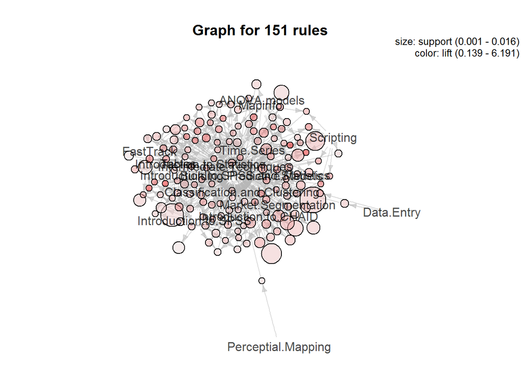

```r
plot(rules_2, method="graph")
```

```r
rules_3<-subset(rules, rhs %in% 'Intermediate.Techniques')
rules_3_sort<-sort(rules_3,by="lift")
inspect(rules_3_sort[1:20])
```

```
##      lhs                                      rhs                           support confidence     lift
## [1]  {Data.Entry,
##       Mapinfo}                             => {Intermediate.Techniques} 0.001404494  1.0000000 9.843318
## [2]  {Building.Predictive.Models,
##       Data.Entry}                          => {Intermediate.Techniques} 0.001872659  1.0000000 9.843318
## [3]  {Building.Predictive.Models,
##       Data.Entry,
##       Mapinfo}                             => {Intermediate.Techniques} 0.001404494  1.0000000 9.843318
## [4]  {Building.Predictive.Models,
##       Data.Entry,
##       Introduction.to.SPSS}                => {Intermediate.Techniques} 0.001404494  1.0000000 9.843318
## [5]  {Answertree,
##       Classification.and.Clustering,
##       Tables}                              => {Intermediate.Techniques} 0.001404494  1.0000000 9.843318
## [6]  {Mapinfo,
##       Tables,
##       Time.Series}                         => {Intermediate.Techniques} 0.001872659  1.0000000 9.843318
## [7]  {Introduction.to.SPSS.and.Statistics,
##       Mapinfo,
##       Tables}                              => {Intermediate.Techniques} 0.001404494  1.0000000 9.843318
## [8]  {Introduction.to.SPSS,
##       Market.Segmentation,
##       Tables}                              => {Intermediate.Techniques} 0.001404494  1.0000000 9.843318
## [9]  {FastTrack,
##       Introduction.to.SPSS,
##       Tables}                              => {Intermediate.Techniques} 0.001404494  1.0000000 9.843318
## [10] {Introduction.to.CHAID,
##       Introduction.to.SPSS.and.Statistics,
##       Tables}                              => {Intermediate.Techniques} 0.001872659  1.0000000 9.843318
## [11] {Building.Predictive.Models,
##       Introduction.to.SPSS,
##       Tables}                              => {Intermediate.Techniques} 0.001872659  1.0000000 9.843318
## [12] {Introduction.to.SPSS,
##       Introduction.to.SPSS.and.Statistics,
##       Tables}                              => {Intermediate.Techniques} 0.001404494  1.0000000 9.843318
## [13] {FastTrack,
##       Mapinfo,
##       Time.Series}                         => {Intermediate.Techniques} 0.001404494  1.0000000 9.843318
## [14] {FastTrack,
##       Introduction.to.SPSS.and.Statistics,
##       Time.Series}                         => {Intermediate.Techniques} 0.001404494  1.0000000 9.843318
## [15] {FastTrack,
##       Introduction.to.SPSS,
##       Introduction.to.SPSS.and.Statistics} => {Intermediate.Techniques} 0.001404494  1.0000000 9.843318
## [16] {Introduction.to.SPSS.and.Statistics,
##       Tables,
##       Time.Series}                         => {Intermediate.Techniques} 0.002808989  0.8571429 8.437130
## [17] {Answertree,
##       Classification.and.Clustering}       => {Intermediate.Techniques} 0.002340824  0.8333333 8.202765
## [18] {Introduction.to.Statistics,
##       Tables,
##       Time.Series}                         => {Intermediate.Techniques} 0.002340824  0.8333333 8.202765
## [19] {Building.Predictive.Models,
##       Tables,
##       Time.Series}                         => {Intermediate.Techniques} 0.002340824  0.8333333 8.202765
## [20] {Introduction.to.SPSS.and.Statistics,
##       Introduction.to.Statistics,
##       Tables}                              => {Intermediate.Techniques} 0.002340824  0.8333333 8.202765
```

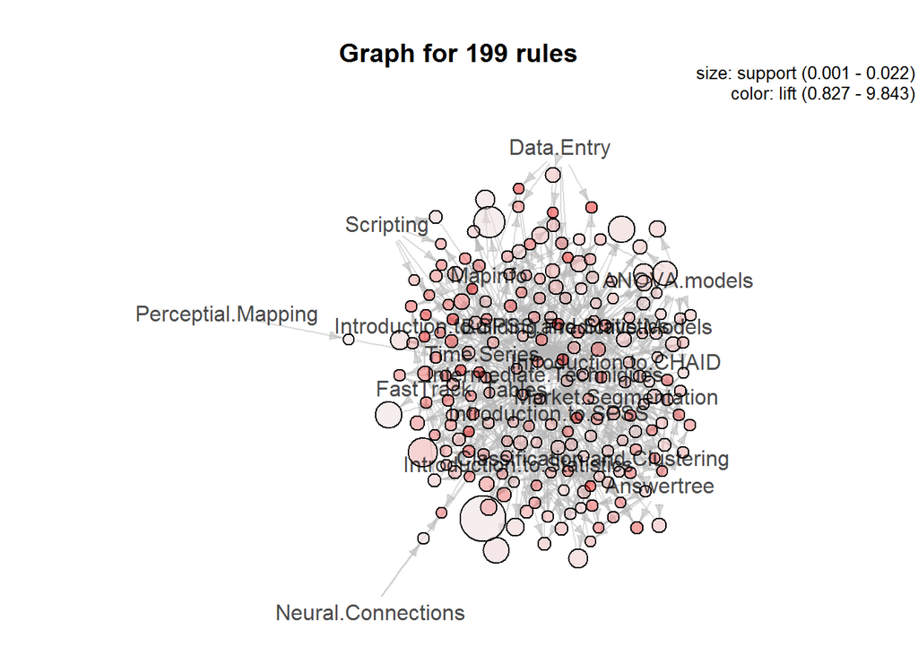

```r
plot(rules_3, method="graph")
```

# Rules including Spendings and courses

Next, I want to see if people spend more than average spendings, which courses they are going to choose.

```r
rules_spend <- apriori(txn[,c(1,17:34)], parameter = list(minlen = 2, maxlen = 4,
                                   supp = 0.001, conf = 0.001))
```

```
## Apriori
##
## Parameter specification:
##  confidence minval smax arem  aval originalSupport maxtime support minlen
##       0.001    0.1    1 none FALSE            TRUE       5   0.001      2
##  maxlen target   ext
##       4  rules FALSE
##
## Algorithmic control:
##  filter tree heap memopt load sort verbose
##     0.1 TRUE TRUE  FALSE TRUE    2    TRUE
##
## Absolute minimum support count: 2
##
## set item appearances ...[0 item(s)] done [0.00s].
## set transactions ...[19 item(s), 2136 transaction(s)] done [0.00s].
## sorting and recoding items ... [19 item(s)] done [0.00s].
## creating transaction tree ... done [0.00s].
## checking subsets of size 1 2 3 4
```

```
##  done [0.00s].
## writing ... [4455 rule(s)] done [0.00s].
## creating S4 object  ... done [0.00s].
```

[output not shown]

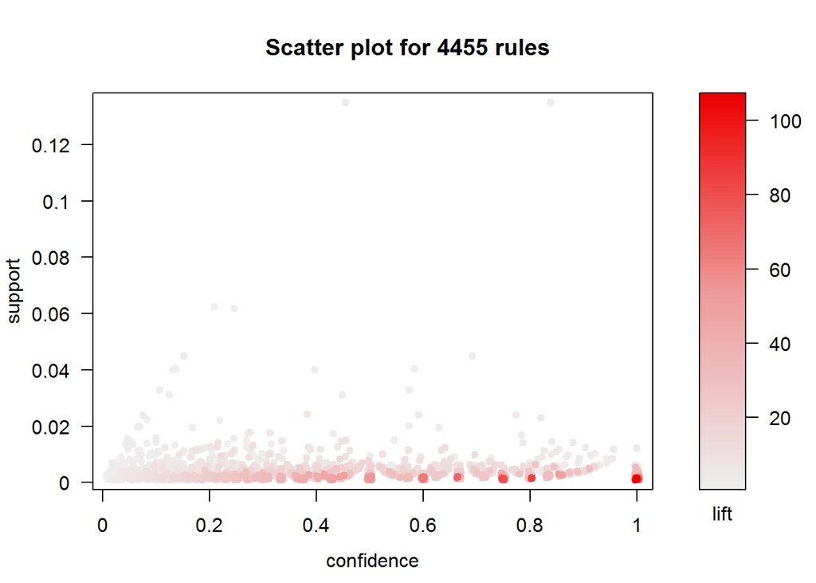

```r
plot(rules_spend, type="scatterplot",
     measure=c("confidence", "support"), shading="lift")
```

```r
rules_spend1<-subset(rules_spend, rhs %in% 'Total.spend')
rules_sort_spend<-sort(rules_spend1,by="lift")
inspect(rules_sort_spend[1:20])
```

```
##      lhs                                rhs               support confidence     lift
## [1]  {Scripting,
##       Tables}                        => {Total.spend} 0.001872659          1 3.342723
## [2]  {Neural.Connections,
##       ANOVA.models}                  => {Total.spend} 0.001404494          1 3.342723
## [3]  {Classification.and.Clustering,
##       Neural.Connections}            => {Total.spend} 0.001872659          1 3.342723
## [4]  {Answertree,
##       Perceptial.Mapping}            => {Total.spend} 0.001872659          1 3.342723
## [5]  {Answertree,
##       ANOVA.models}                  => {Total.spend} 0.001872659          1 3.342723
## [6]  {Answertree,
##       Tables}                        => {Total.spend} 0.002340824          1 3.342723
## [7]  {Answertree,
##       Mapinfo}                       => {Total.spend} 0.001404494          1 3.342723
## [8]  {Answertree,
##       Time.Series}                   => {Total.spend} 0.001872659          1 3.342723
## [9]  {Answertree,
##       Classification.and.Clustering} => {Total.spend} 0.002808989          1 3.342723
## [10] {Answertree,
##       Market.Segmentation}           => {Total.spend} 0.003745318          1 3.342723
## [11] {Answertree,
##       Introduction.to.CHAID}         => {Total.spend} 0.002808989          1 3.342723
## [12] {Answertree,
##       Introduction.to.Statistics}    => {Total.spend} 0.002808989          1 3.342723
## [13] {Answertree,
##       Building.Predictive.Models}    => {Total.spend} 0.003745318          1 3.342723
## [14] {Answertree,
##       Intermediate.Techniques}       => {Total.spend} 0.003277154          1 3.342723
## [15] {Answertree,
##       Introduction.to.SPSS}          => {Total.spend} 0.003277154          1 3.342723
## [16] {Perceptial.Mapping,
##       Time.Series}                   => {Total.spend} 0.001404494          1 3.342723
## [17] {Intermediate.Techniques,
##       Perceptial.Mapping}            => {Total.spend} 0.001404494          1 3.342723
## [18] {Tables,
##       ANOVA.models}                  => {Total.spend} 0.003277154          1 3.342723
## [19] {Time.Series,
##       ANOVA.models}                  => {Total.spend} 0.003277154          1 3.342723
## [20] {Market.Segmentation,
##       ANOVA.models}                  => {Total.spend} 0.005149813          1 3.342723
```

As we can see from the table, if people choose “Scripting table” and “Tables” they spend more than average, or if they choose “Answertree” and “Anova.models” they spend more than average. This information can be used both by the education centers and customers. Education centers based on this information can suggest different course packages for different customers based on the question how much they are ready to pay(above or below the average).

# Rules including Sector and Courses

```r
rules3 <- apriori(txn[,c(2:6,17:34)], parameter = list(minlen = 2, maxlen = 4,
                                   supp = 0.001, conf = 0.001))
```

```
## Apriori
##
## Parameter specification:
##  confidence minval smax arem  aval originalSupport maxtime support minlen
##       0.001    0.1    1 none FALSE            TRUE       5   0.001      2
##  maxlen target   ext
##       4  rules FALSE
##
## Algorithmic control:
##  filter tree heap memopt load sort verbose
##     0.1 TRUE TRUE  FALSE TRUE    2    TRUE
##
## Absolute minimum support count: 2
##
## set item appearances ...[0 item(s)] done [0.00s].
## set transactions ...[23 item(s), 2136 transaction(s)] done [0.00s].
## sorting and recoding items ... [23 item(s)] done [0.00s].
## creating transaction tree ... done [0.00s].
## checking subsets of size 1 2 3 4
```

```
##  done [0.00s].
## writing ... [4565 rule(s)] done [0.00s].
## creating S4 object  ... done [0.00s].
```

[output not shown]

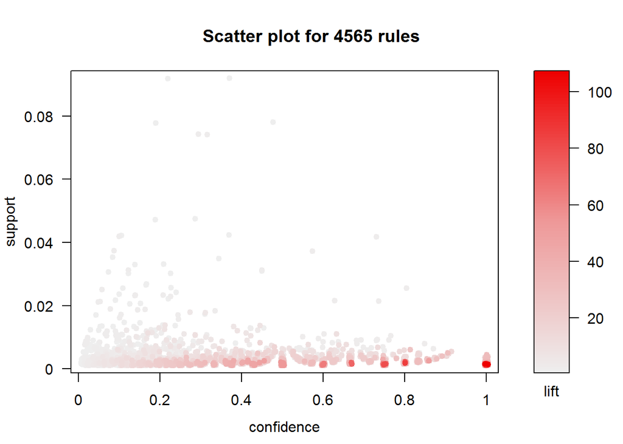

```r
plot(rules3, type="scatterplot",
     measure=c("confidence", "support"), shading="lift")
```

```r
rules_3_1<-subset(rules3, rhs %in% c("Sector.Central Gov\\t","Sector.Commercial","Sector.Education",  "Sector.Health","Sector.Local Gov\\t"))
rules_sort_3<-sort(rules_3_1,by="lift")
inspect(rules_sort_3[1:20])
```

```
##      lhs                                      rhs                         support confidence     lift
## [1]  {FastTrack,
##       Intermediate.Techniques,
##       Introduction.to.SPSS.and.Statistics} => {Sector.Local Gov\t}   0.001404494  0.7500000 4.564103
## [2]  {FastTrack,
##       Introduction.to.SPSS}                => {Sector.Local Gov\t}   0.001872659  0.6666667 4.056980
## [3]  {Introduction.to.SPSS.and.Statistics,
##       Introduction.to.Statistics,
##       Tables}                              => {Sector.Local Gov\t}   0.001872659  0.6666667 4.056980
## [4]  {FastTrack,
##       Intermediate.Techniques,
##       Introduction.to.Statistics}          => {Sector.Local Gov\t}   0.001872659  0.6666667 4.056980
## [5]  {FastTrack,
##       Introduction.to.SPSS.and.Statistics,
##       Introduction.to.Statistics}          => {Sector.Local Gov\t}   0.001872659  0.6666667 4.056980
## [6]  {Intermediate.Techniques,
##       Introduction.to.SPSS.and.Statistics,
##       Introduction.to.Statistics}          => {Sector.Local Gov\t}   0.001872659  0.6666667 4.056980
## [7]  {Classification.and.Clustering,
##       Tables,
##       Time.Series}                         => {Sector.Local Gov\t}   0.001404494  0.6000000 3.651282
## [8]  {FastTrack,
##       Introduction.to.SPSS.and.Statistics,
##       Tables}                              => {Sector.Local Gov\t}   0.001404494  0.6000000 3.651282
## [9]  {Intermediate.Techniques,
##       Mapinfo,
##       Time.Series}                         => {Sector.Local Gov\t}   0.001404494  0.6000000 3.651282
## [10] {Introduction.to.SPSS.and.Statistics,
##       Mapinfo,
##       Time.Series}                         => {Sector.Local Gov\t}   0.001404494  0.6000000 3.651282
## [11] {Introduction.to.SPSS.and.Statistics,
##       Introduction.to.Statistics,
##       Time.Series}                         => {Sector.Local Gov\t}   0.001404494  0.6000000 3.651282
## [12] {Intermediate.Techniques,
##       Introduction.to.SPSS.and.Statistics,
##       Mapinfo}                             => {Sector.Local Gov\t}   0.001404494  0.6000000 3.651282
## [13] {Introduction.to.SPSS.and.Statistics,
##       Tables,
##       Time.Series}                         => {Sector.Local Gov\t}   0.001872659  0.5714286 3.477411
## [14] {Mapinfo,
##       Market.Segmentation,
##       Time.Series}                         => {Sector.Central Gov\t} 0.001404494  0.7500000 3.166008
## [15] {FastTrack,
##       Introduction.to.SPSS.and.Statistics} => {Sector.Local Gov\t}   0.001872659  0.5000000 3.042735
## [16] {Classification.and.Clustering,
##       Introduction.to.SPSS.and.Statistics,
##       Tables}                              => {Sector.Local Gov\t}   0.001404494  0.5000000 3.042735
## [17] {Introduction.to.Statistics,
##       Tables,
##       Time.Series}                         => {Sector.Local Gov\t}   0.001404494  0.5000000 3.042735
## [18] {Introduction.to.SPSS,
##       Introduction.to.Statistics,
##       Tables}                              => {Sector.Local Gov\t}   0.002340824  0.5000000 3.042735
## [19] {Classification.and.Clustering,
##       Introduction.to.SPSS.and.Statistics,
##       Time.Series}                         => {Sector.Local Gov\t}   0.001404494  0.5000000 3.042735
## [20] {Intermediate.Techniques,
##       Introduction.to.Statistics,
##       Time.Series}                         => {Sector.Local Gov\t}   0.001404494  0.5000000 3.042735
```

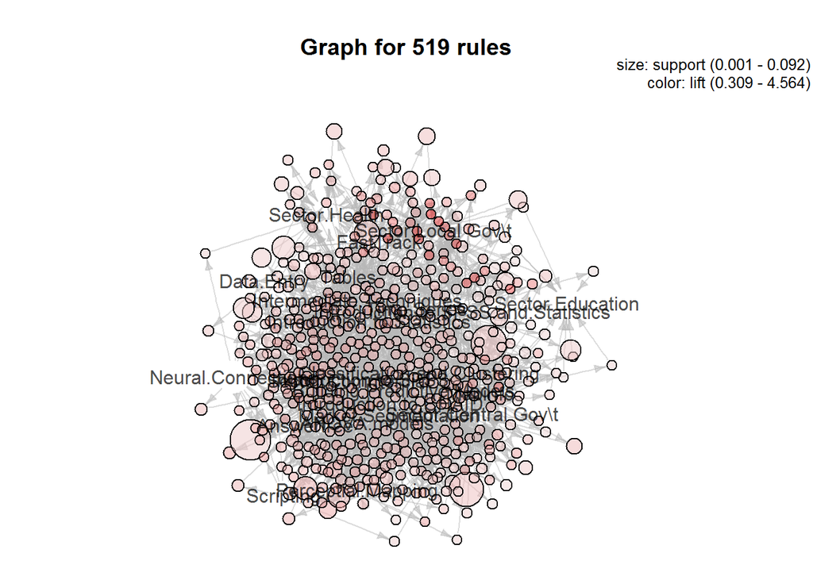

```r
plot(rules_3_1, method="graph")
```

# Rules including Venue and Courses

```r
rules4 <- apriori(txn[,7:34], parameter = list(minlen = 2, maxlen = 4,
                                   supp = 0.001, conf = 0.001))
```

```
## Apriori
##
## Parameter specification:
##  confidence minval smax arem  aval originalSupport maxtime support minlen
##       0.001    0.1    1 none FALSE            TRUE       5   0.001      2
##  maxlen target   ext
##       4  rules FALSE
##
## Algorithmic control:
##  filter tree heap memopt load sort verbose
##     0.1 TRUE TRUE  FALSE TRUE    2    TRUE
##
## Absolute minimum support count: 2
##
## set item appearances ...[0 item(s)] done [0.00s].
## set transactions ...[28 item(s), 2136 transaction(s)] done [0.00s].
## sorting and recoding items ... [28 item(s)] done [0.00s].
## creating transaction tree ... done [0.00s].
## checking subsets of size 1 2 3 4
```

```
##  done [0.00s].
## writing ... [6825 rule(s)] done [0.00s].
## creating S4 object  ... done [0.00s].
```

[output not shown]

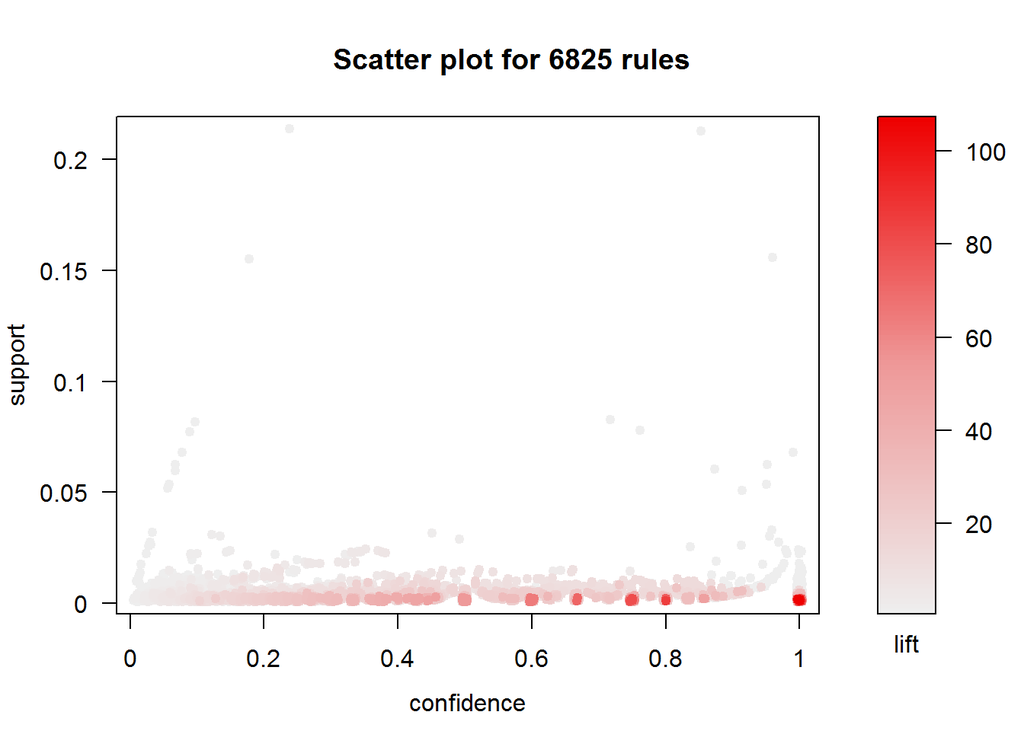

```r
plot(rules4, type="scatterplot",
     measure=c("confidence", "support"), shading="lift")
```

```r
rules_4_1<-subset(rules4, rhs %in% c("Venue.Belfast","Venue.Edinburgh","Venue.IDM","Venue.Manchester", "Venue.Newcastle","Venue.Sheffield","Venue.SPSS WOKING"))
rules_sort_5<-sort(rules_4_1,by="lift")
inspect(rules_sort_5[1:20])
```

```
##      lhs                                      rhs                    support confidence      lift
## [1]  {FastTrack,
##       Intermediate.Techniques}             => {Venue.Newcastle}  0.001404494 0.13043478 21.431438
## [2]  {Intermediate.Techniques,
##       Introduction.to.SPSS.and.Statistics} => {Venue.Newcastle}  0.001404494 0.10344828 16.997347
## [3]  {Market.Segmentation}                 => {Venue.IDM}        0.005149813 0.16417910 14.027463
## [4]  {Building.Predictive.Models,
##       Market.Segmentation}                 => {Venue.IDM}        0.001404494 0.10000000  8.544000
## [5]  {Data.Entry}                          => {Venue.Belfast}    0.001872659 0.17391304  7.903793
## [6]  {FastTrack,
##       Intermediate.Techniques}             => {Venue.Belfast}    0.001404494 0.13043478  5.927845
## [7]  {FastTrack}                           => {Venue.Newcastle}  0.003745318 0.03278689  5.387137
## [8]  {Intermediate.Techniques}             => {Venue.Newcastle}  0.003277154 0.03225806  5.300248
## [9]  {FastTrack}                           => {Venue.Edinburgh}  0.010767790 0.09426230  4.283920
## [10] {FastTrack}                           => {Venue.Belfast}    0.008895131 0.07786885  3.538891
## [11] {Intermediate.Techniques,
##       Introduction.to.SPSS}                => {Venue.Sheffield}  0.001404494 0.06382979  3.170708
## [12] {Introduction.to.SPSS}                => {Venue.Sheffield}  0.014981273 0.05970149  2.965637
## [13] {Intermediate.Techniques}             => {Venue.Manchester} 0.008426966 0.08294931  2.725842
## [14] {Intermediate.Techniques}             => {Venue.Belfast}    0.006086142 0.05990783  2.722620
## [15] {FastTrack}                           => {Venue.Manchester} 0.007022472 0.06147541  2.020177
## [16] {Introduction.to.SPSS.and.Statistics} => {Venue.Newcastle}  0.001872659 0.01159420  1.905017
## [17] {Intermediate.Techniques}             => {Venue.Edinburgh}  0.004213483 0.04147465  1.884891
## [18] {Building.Predictive.Models}          => {Venue.IDM}        0.001404494 0.02158273  1.844029
## [19] {Introduction.to.Statistics}          => {Venue.Manchester} 0.003745318 0.05442177  1.788383
## [20] {Mapinfo}                             => {Venue.Sheffield}  0.001872659 0.03361345  1.669728
```

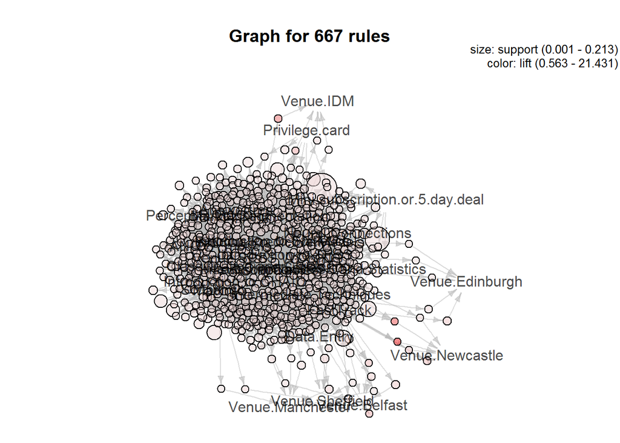

```r
plot(rules_4_1, method="graph")
```